# 重賞レース予測レポート【毎時自動更新中】

作成日時: 2025/07/27 14:04:29

☞ [マニュアル(pdf)](https://ryutoro-galois.github.io/keiba-predictor/manual/manual.pdf)

☞ 過去5年の同一レース結果: [2024年](https://ryutoro-galois.github.io/keiba-predictor/report/PredResult_2024y_raceDate_20240721_20240721.html), [2023年](https://ryutoro-galois.github.io/keiba-predictor/report/PredResult_2023y_raceDate_20230723_20230723.html), [2022年](https://ryutoro-galois.github.io/keiba-predictor/report/PredResult_2022y_raceDate_20220724_20220724.html), [2021年](https://ryutoro-galois.github.io/keiba-predictor/report/PredResult_2021y_raceDate_20210725_20210725.html), [2020年](https://ryutoro-galois.github.io/keiba-predictor/report/PredResult_2020y_raceDate_20200726_20200726.html)

☞ 過去4週間の別レース結果: [1週前(7/20)](https://ryutoro-galois.github.io/keiba-predictor/report/PredResult_2025y_raceDate_20250720_20250720.html), [2週前(7/13)](https://ryutoro-galois.github.io/keiba-predictor/report/PredResult_2025y_raceDate_20250713_20250713.html), [3週前(7/6)](https://ryutoro-galois.github.io/keiba-predictor/report/PredResult_2025y_raceDate_20250706_20250706.html), [4週前(6/29)](https://ryutoro-galois.github.io/keiba-predictor/report/PredResult_2025y_raceDate_20250629_20250629.html)

☞ netkeiba: [関屋記念(GⅢ)](https://race.netkeiba.com/race/shutuba.html?race_id=202504020207&rf=race_list), [東海ステークス(GⅢ)](https://race.netkeiba.com/race/shutuba.html?race_id=202507030207&rf=race_list)

## 0. 推し馬予測 (AI予測)

### 【関屋記念(GⅢ) 2025/07/27(日)】

- 本命(◎): 1-3着内確率(勝負強さ)が1位の馬
- 対抗(◯): 1-3着内確率が2-N位(20%程度以上)の中で予測タイムが最も速い馬
- 3番手(▲): 1-3着内確率が2-N位(20%程度以上)のでダークホース確率が最も高い馬
- 穴: ダークホース確率が上位1-M位(40%程度以上)の中で1-3着内確率が最も高い馬

| 推し馬 | 枠番 | 馬番 | 人気 | オッズ | 馬名 | 騎手 | 調教師 | 予測タイム(sec) | 1_順位 | 1-3着内確率(%) | 2_順位 | ﾀﾞｰｸﾎｰｽ確率(%) | 3_順位 |
| --- | --- | --- | --- | --- | --- | --- | --- | --- | --- | --- | --- | --- | --- |
| 本命(◎) | 6 | 11 | 2 | 5.8 | ボンドガール | Ｃ．ルメール | 手塚貴久 | 97.5 | 16 | 60.7 | 1 | 0.4 | 16 |
| 対抗(◯) | 8 | 16 | 3 | 7.2 | フォーチュンタイム | 三浦皇成 | 吉岡辰弥 | 94.3 | 2 | 45.5 | 2 | 0.4 | 17 |
| 3番手(▲) | 1 | 2 | 9 | 14.8 | シンフォーエバー | 江田照男 | 森秀行 | 94.7 | 6 | 25.1 | 5 | 1.7 | 10 |
| 穴 | 4 | 7 | 12 | 36.8 | ハクサンバード | 小崎綾也 | 高橋一哉 | 95.6 | 7 | 10.4 | 9 | 40.1 | 1 |

- 本命(◎): 1-3着内確率(勝負強さ)が1位の馬
- 対抗(◯): 1-3着内確率が2-N位(20%程度以上)の中で予測タイムが最も速い馬
- 3番手(▲): 1-3着内確率が2-N位(20%程度以上)のでダークホース確率が最も高い馬
- 穴: ダークホース確率が上位1-M位(40%程度以上)の中で1-3着内確率が最も高い馬

| 推し馬 | 枠番 | 馬番 | 人気 | オッズ | 馬名 | 騎手 | 調教師 | 予測タイム(sec) | 1_順位 | 1-3着内確率(%) | 2_順位 | ﾀﾞｰｸﾎｰｽ確率(%) | 3_順位 |
| --- | --- | --- | --- | --- | --- | --- | --- | --- | --- | --- | --- | --- | --- |
| 本命(◎) | 4 | 8 | 3 | 6.1 | インユアパレス | 川田将雅 | 須貝尚介 | 114.0 | 2 | 52.4 | 1 | 0.6 | 15 |
| 対抗(◯) | 1 | 2 | 1 | 3.8 | ビダーヤ | 坂井瑠星 | 矢作芳人 | 109.8 | 1 | 26.1 | 5 | 0.6 | 16 |
| 3番手(▲) | 2 | 4 | 7 | 17.9 | エートラックス | Ａ．バデル | 宮本博 | 114.2 | 4 | 24.5 | 6 | 1.8 | 10 |
| 穴 | 8 | 15 | 13 | 56.3 | リジル | 田口貫太 | 奥村豊 | 114.1 | 3 | 11.0 | 8 | 37.4 | 1 |

## 1. 予測チャート (タイム/勝負強さ)

### 【関屋記念(GⅢ)】

2025/07/27(日), 04_新潟, 芝左外1600m

[interactive chart not shown]

[interactive chart not shown]

## 2. オッズモニタリング (毎時)

### 【関屋記念】

[interactive chart not shown]

### 【東海ステークス】

[interactive chart not shown]

## 3. 出馬表

### 【関屋記念 2025/07/27(日) 】

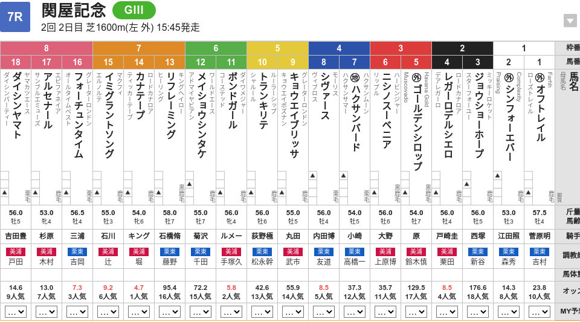

### 【東海ステークス 2025/07/27(日) 】

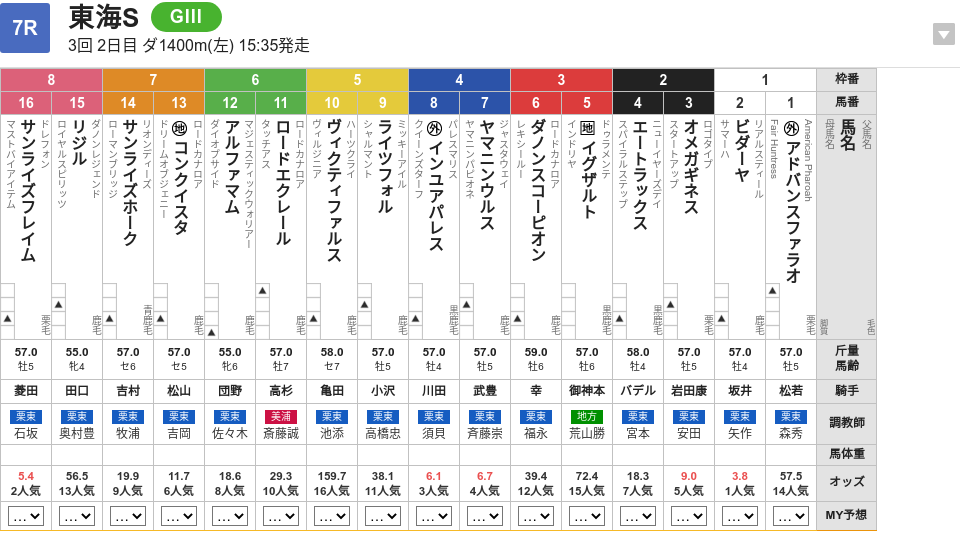

## 4. 単勝予測結果

### 【関屋記念(GⅢ) 2025/07/27(日)】

| 枠番 | 馬番 | 人気 | オッズ | 馬名 | 騎手 | 調教師 | 予測タイム(sec) | 1_順位 | 1-3着内確率(%) | 2_順位 | ﾀﾞｰｸﾎｰｽ確率(%) | 3_順位 |
| --- | --- | --- | --- | --- | --- | --- | --- | --- | --- | --- | --- | --- |
| 1 | 1 | 10 | 23.8 | オフトレイル | 菅原明良 | 吉村圭司 | 95.8 | 8.0 | 17.6 | 8 | 34.8 | 2 |
| 1 | 2 | 9 | 14.8 | シンフォーエバー | 江田照男 | 森秀行 | 94.7 | 6.0 | 25.1 | 5 | 1.7 | 10 |
| 2 | 3 | 18 | 192.9 | ジョウショーホープ | 西塚洸二 | 新谷功一 | 96.7 | 9.0 | 3.1 | 16 | 7.1 | 7 |
| 2 | 4 | 4 | 8.4 | レガーロデルシエロ | 戸崎圭太 | 栗田徹 | 96.7 | 11.0 | 20.4 | 6 | 0.9 | 14 |
| 3 | 5 | 17 | 136.5 | ゴールデンシロップ | 原優介 | 鈴木慎太郎 | 96.9 | 13.0 | 4.7 | 13 | 8.0 | 6 |
| 3 | 6 | 11 | 36.4 | ニシノスーベニア | 大野拓弥 | 上原博之 | 97.8 | 17.0 | 3.4 | 15 | 10.5 | 3 |
| 4 | 7 | 12 | 36.8 | ハクサンバード | 小崎綾也 | 高橋一哉 | 95.6 | 7.0 | 10.4 | 9 | 40.1 | 1 |
| 4 | 8 | 5 | 8.5 | シヴァース | 内田博幸 | 友道康夫 | 94.5 | 4.0 | 35.9 | 3 | 0.7 | 15 |
| 5 | 9 | 14 | 59.5 | キョウエイブリッサ | 丸田恭介 | 武市康男 | 96.9 | 14.5 | 2.4 | 18 | 8.1 | 5 |
| 5 | 10 | 13 | 42.1 | トランキリテ | 荻野極 | 松永幹夫 | 96.7 | 10.0 | 3.5 | 14 | 6.0 | 9 |

[output cut: 8 more lines]

| 枠番 | 馬番 | 人気 | オッズ | 馬名 | 騎手 | 調教師 | 予測タイム(sec) | 1_順位 | 1-3着内確率(%) | 2_順位 | ﾀﾞｰｸﾎｰｽ確率(%) | 3_順位 |
| --- | --- | --- | --- | --- | --- | --- | --- | --- | --- | --- | --- | --- |
| 1 | 1 | 14 | 57.3 | アドバンスファラオ | 松若風馬 | 森秀行 | 117.4 | 12 | 3.6 | 15 | 13.3 | 6 |
| 1 | 2 | 1 | 3.8 | ビダーヤ | 坂井瑠星 | 矢作芳人 | 109.8 | 1 | 26.1 | 5 | 0.6 | 16 |
| 2 | 3 | 5 | 9.0 | オメガギネス | 岩田康誠 | 安田翔伍 | 115.5 | 8 | 35.8 | 4 | 1.8 | 9 |
| 2 | 4 | 7 | 17.9 | エートラックス | Ａ．バデル | 宮本博 | 114.2 | 4 | 24.5 | 6 | 1.8 | 10 |
| 3 | 5 | 15 | 72.8 | イグザルト | 御神本訓史 | 荒山勝徳 | 116.7 | 9 | 3.2 | 16 | 10.7 | 7 |
| 3 | 6 | 12 | 39.7 | ダノンスコーピオン | 幸英明 | 福永祐一 | 118.6 | 14 | 6.8 | 12 | 15.2 | 4 |
| 4 | 7 | 4 | 6.6 | ヤマニンウルス | 武豊 | 斉藤崇史 | 117.2 | 11 | 40.2 | 3 | 0.8 | 13 |
| 4 | 8 | 3 | 6.1 | インユアパレス | 川田将雅 | 須貝尚介 | 114.0 | 2 | 52.4 | 1 | 0.6 | 15 |
| 5 | 9 | 11 | 39.2 | ライツフォル | 小沢大仁 | 高橋義忠 | 114.5 | 5 | 10.7 | 10 | 34.5 | 2 |
| 5 | 10 | 16 | 156.7 | ヴィクティファルス | 亀田温心 | 池添学 | 119.9 | 16 | 4.0 | 14 | 16.0 | 3 |

[output cut: 6 more lines]

## 5. 人気と着順の乖離率推移

### 【関屋記念_1990y_2019y】

[interactive chart not shown]

### 【東海ステークス_1997y_2019y】

[interactive chart not shown]

### 【関屋記念_1990y_2019y】

| No | 開催年 | 不整合率(%) | 頭数 | 人気別着順(1-3位) | 人気別着順(全体) |
| --- | --- | --- | --- | --- | --- |
| 30 | 2019 | 43.1 | 17頭 | 1-6-4 | 1\|6\|4\|8\|5\|11\|13\|9\|3\|7\|12\|10\|15\|2\|14\|16\|17 |
| 29 | 2018 | 29.1 | 15頭 | 1-5-3 | 1\|5\|3\|11\|8\|2\|9\|10\|12\|4\|6\|7\|13\|15\|14 |
| 28 | 2017 | 54.5 | 16頭 | 7-4-5 | 7\|4\|5\|6\|8\|2\|14\|15\|16\|11\|13\|1\|10\|9\|3\|12 |
| 27 | 2016 | 37.9 | 18頭 | 3-7-1 | 3\|7\|1\|14\|2\|6\|13\|8\|5\|17\|4\|9\|16\|15\|10\|11\|12\|18 |
| 26 | 2015 | 36.8 | 12頭 | 2-6-9 | 2\|6\|9\|8\|7\|10\|1\|3\|5\|11\|4\|12 |
| 25 | 2014 | 44.4 | 16頭 | 4-1-6 | 4\|1\|6\|8\|10\|12\|11\|13\|3\|5\|14\|2\|9\|15\|7\|16 |
| 24 | 2013 | 33.5 | 17頭 | 4-1-3 | 4\|1\|3\|2\|9\|15\|6\|13\|12\|5\|7\|16\|10\|17\|11\|14\|18 |
| 23 | 2012 | 43.9 | 18頭 | 1-5-8 | 1\|5\|8\|4\|6\|7\|12\|18\|10\|13\|14\|3\|17\|11\|16\|9\|15\|2 |
| 22 | 2011 | 49.0 | 12頭 | 4-2-3 | 4\|2\|3\|7\|1\|5\|11\|10\|9\|6\|8\|12 |
| 21 | 2010 | 40.0 | 18頭 | 6-2-10 | 6\|2\|10\|13\|5\|1\|7\|4\|3\|14\|16\|9\|8\|11\|15\|12\|17\|18 |

[output cut: 20 more lines]

### 【東海ステークス_1997y_2019y】

| No | 開催年 | 不整合率(%) | 頭数 | 人気別着順(1-3位) | 人気別着順(全体) |
| --- | --- | --- | --- | --- | --- |
| 21 | 2019 | 19.5 | 13頭 | 1-2-4 | 1\|2\|4\|6\|8\|7\|10\|5\|12\|13\|9\|3\|11 |
| 20 | 2018 | 36.7 | 16頭 | 1-13-6 | 1\|13\|6\|14\|5\|10\|4\|9\|2\|15\|8\|7\|3\|16\|11\|12 |
| 19 | 2017 | 32.3 | 16頭 | 1-12-10 | 1\|12\|10\|13\|11\|3\|8\|2\|7\|15\|6\|4\|14\|5\|16\|9 |
| 18 | 2016 | 40.7 | 12頭 | 4-2-1 | 4\|2\|1\|11\|10\|5\|6\|7\|8\|9\|3\|12 |
| 17 | 2015 | 36.7 | 14頭 | 1-9-3 | 1\|9\|3\|10\|7\|13\|6\|4\|11\|12\|2\|8\|5\|14 |
| 16 | 2014 | 26.4 | 16頭 | 1-3-8 | 1\|3\|8\|9\|4\|12\|10\|2\|5\|6\|7\|11\|14\|15\|13\|16 |
| 15 | 2013 | 30.7 | 16頭 | 4-8-1 | 4\|8\|1\|7\|2\|6\|3\|9\|15\|11\|16\|10\|5\|12\|13\|14 |
| 14 | 2012 | 65.9 | 15頭 | 4-3-11 | 4\|3\|11\|6\|2\|12\|13\|8\|9\|1\|10\|14\|15\|7\|5 |
| 13 | 2011 | 42.5 | 14頭 | 2-6-5 | 2\|6\|5\|4\|1\|3\|12\|8\|13\|11\|10\|7\|9\|14 |
| 12 | 2010 | 40.6 | 15頭 | 3-1-10 | 3\|1\|10\|5\|8\|9\|12\|2\|6\|11\|4\|14\|7\|13\|15 |

[output cut: 11 more lines]

## 6. 1-3番人気馬の着順分類予測

### 【関屋記念】

| 分類 | 凡例 | 発生確率(%) | 当該レース | 当該レースランク | 直近1年間 |
| --- | --- | --- | --- | --- | --- |
| 1: 1番人気のみ (1_pop1) | 1 \| * \| * | 18.7 | 0.55 | 0.55 | 0.37 |
| 4: 1,2番人気のみ (4_pop12) | 1 \| 2 \| * | 17.1 | 1.20 | 1.20 | 0.34 |
| 8: 1,2,3番人気すべて着外 (8_darkhorse) | * \| * \| * | 14.4 | 1.67 | 1.67 | 0.00 |
| 5: 1,3番人気のみ (5_pop13) | 1 \| 3 \| * | 14.3 | 0.62 | 0.62 | 0.00 |
| 2: 2番人気のみ (2_pop2) | 2 \| * \| * | 9.8 | 1.14 | 1.14 | 0.00 |
| 6: 2,3番人気のみ (6_pop23) | 2 \| 3 \| * | 9.4 | 1.09 | 1.09 | 0.00 |
| 3: 3番人気のみ (3_pop3) | 3 \| * \| * | 9.1 | 3.14 | 3.14 | 0.00 |
| 7: 1,2,3番人気すべて着内 (7_pop123) | 1 \| 2 \| 3 | 7.1 | 0.00 | 0.00 | 0.00 |

### 【東海ステークス】

| 分類 | 凡例 | 発生確率(%) | 当該レース | 当該レースランク | 直近1年間 |
| --- | --- | --- | --- | --- | --- |
| 4: 1,2番人気のみ (4_pop12) | 1 \| 2 \| * | 19.5 | 0.61 | 0.61 | 0.39 |
| 1: 1番人気のみ (1_pop1) | 1 \| * \| * | 17.6 | 0.98 | 0.98 | 0.35 |
| 5: 1,3番人気のみ (5_pop13) | 1 \| 3 \| * | 14.4 | 1.01 | 1.01 | 0.00 |
| 8: 1,2,3番人気すべて着外 (8_darkhorse) | * \| * \| * | 12.7 | 1.79 | 1.79 | 0.00 |
| 2: 2番人気のみ (2_pop2) | 2 \| * \| * | 10.3 | 0.96 | 0.96 | 0.00 |
| 3: 3番人気のみ (3_pop3) | 3 \| * \| * | 9.7 | 1.37 | 1.37 | 0.00 |
| 6: 2,3番人気のみ (6_pop23) | 2 \| 3 \| * | 8.8 | 2.44 | 2.44 | 0.00 |
| 7: 1,2,3番人気すべて着内 (7_pop123) | 1 \| 2 \| 3 | 7.1 | 1.00 | 1.00 | 0.00 |

## 7. 3連複予測結果

### 【関屋記念(GⅢ) 2025/07/27(日)】

| 分類 | 馬番 | 枠番 | 人気 | 平均予測タイム(sec) | 1-3着内確率(%) | ﾀﾞｰｸﾎｰｽ確率(%) | 馬名 | 騎手 | 調教師 |
| --- | --- | --- | --- | --- | --- | --- | --- | --- | --- |
| 6: 2,3番人気のみ (6_pop23) | 11-16-8 | 6-8-4 | 2-3-5 | 95.43 | 9.91 | 0.00 | ボンドガール \| フォーチュンタイム \| シヴァース | Ｃ．ルメール \| 三浦皇成 \| 内田博幸 | 手塚貴久 \| 吉岡辰弥 \| 友道康夫 |
| 6: 2,3番人気のみ (6_pop23) | 11-16-15 | 6-8-7 | 2-3-6 | 95.47 | 8.76 | 0.00 | ボンドガール \| フォーチュンタイム \| イミグラントソング | Ｃ．ルメール \| 三浦皇成 \| 石川裕紀人 | 手塚貴久 \| 吉岡辰弥 \| 辻哲英 |
| 6: 2,3番人気のみ (6_pop23) | 11-16-2 | 6-8-1 | 2-3-9 | 95.50 | 6.92 | 0.00 | ボンドガール \| フォーチュンタイム \| シンフォーエバー | Ｃ．ルメール \| 三浦皇成 \| 江田照男 | 手塚貴久 \| 吉岡辰弥 \| 森秀行 |
| 2: 2番人気のみ (2_pop2) | 11-8-15 | 6-4-7 | 2-5-6 | 95.53 | 6.91 | 0.00 | ボンドガール \| シヴァース \| イミグラントソング | Ｃ．ルメール \| 内田博幸 \| 石川裕紀人 | 手塚貴久 \| 友道康夫 \| 辻哲英 |
| 6: 2,3番人気のみ (6_pop23) | 11-16-4 | 6-8-2 | 2-3-4 | 96.17 | 5.64 | 0.00 | ボンドガール \| フォーチュンタイム \| レガーロデルシエロ | Ｃ．ルメール \| 三浦皇成 \| 戸崎圭太 | 手塚貴久 \| 吉岡辰弥 \| 栗田徹 |
| 6: 2,3番人気のみ (6_pop23) | 11-16-17 | 6-8-8 | 2-3-7 | 95.43 | 5.56 | 0.00 | ボンドガール \| フォーチュンタイム \| アルセナール | Ｃ．ルメール \| 三浦皇成 \| 杉原誠人 | 手塚貴久 \| 吉岡辰弥 \| 木村哲也 |
| 2: 2番人気のみ (2_pop2) | 11-8-2 | 6-4-1 | 2-5-9 | 95.57 | 5.45 | 0.00 | ボンドガール \| シヴァース \| シンフォーエバー | Ｃ．ルメール \| 内田博幸 \| 江田照男 | 手塚貴久 \| 友道康夫 \| 森秀行 |
| 3: 3番人気のみ (3_pop3) | 16-8-15 | 8-4-7 | 3-5-6 | 94.47 | 5.18 | 0.00 | フォーチュンタイム \| シヴァース \| イミグラントソング | 三浦皇成 \| 内田博幸 \| 石川裕紀人 | 吉岡辰弥 \| 友道康夫 \| 辻哲英 |
| 6: 2,3番人気のみ (6_pop23) | 11-16-1 | 6-8-1 | 2-3-10 | 95.87 | 4.87 | 0.00 | ボンドガール \| フォーチュンタイム \| オフトレイル | Ｃ．ルメール \| 三浦皇成 \| 菅原明良 | 手塚貴久 \| 吉岡辰弥 \| 吉村圭司 |
| 2: 2番人気のみ (2_pop2) | 11-15-2 | 6-7-1 | 2-6-9 | 95.60 | 4.82 | 0.00 | ボンドガール \| イミグラントソング \| シンフォーエバー | Ｃ．ルメール \| 石川裕紀人 \| 江田照男 | 手塚貴久 \| 辻哲英 \| 森秀行 |

[output cut: 806 more lines]

| 分類 | 馬番 | 枠番 | 人気 | 平均予測タイム(sec) | 1-3着内確率(%) | ﾀﾞｰｸﾎｰｽ確率(%) | 馬名 | 騎手 | 調教師 |
| --- | --- | --- | --- | --- | --- | --- | --- | --- | --- |
| 6: 2,3番人気のみ (6_pop23) | 16-8-7 | 8-4-4 | 2-3-4 | 115.53 | 8.82 | 0.00 | サンライズフレイム \| インユアパレス \| ヤマニンウルス | 菱田裕二 \| 川田将雅 \| 武豊 | 石坂公一 \| 須貝尚介 \| 斉藤崇史 |
| 6: 2,3番人気のみ (6_pop23) | 16-8-3 | 8-4-2 | 2-3-5 | 114.97 | 7.85 | 0.00 | サンライズフレイム \| インユアパレス \| オメガギネス | 菱田裕二 \| 川田将雅 \| 岩田康誠 | 石坂公一 \| 須貝尚介 \| 安田翔伍 |
| 3: 3番人気のみ (3_pop3) | 8-7-3 | 4-4-2 | 3-4-5 | 115.57 | 7.54 | 0.00 | インユアパレス \| ヤマニンウルス \| オメガギネス | 川田将雅 \| 武豊 \| 岩田康誠 | 須貝尚介 \| 斉藤崇史 \| 安田翔伍 |
| 2: 2番人気のみ (2_pop2) | 16-7-3 | 8-4-2 | 2-4-5 | 116.03 | 6.03 | 0.00 | サンライズフレイム \| ヤマニンウルス \| オメガギネス | 菱田裕二 \| 武豊 \| 岩田康誠 | 石坂公一 \| 斉藤崇史 \| 安田翔伍 |
| 7: 1,2,3番人気すべて着内 (7_pop123) | 2-16-8 | 1-8-4 | 1-2-3 | 113.07 | 5.72 | 0.00 | ビダーヤ \| サンライズフレイム \| インユアパレス | 坂井瑠星 \| 菱田裕二 \| 川田将雅 | 矢作芳人 \| 石坂公一 \| 須貝尚介 |
| 5: 1,3番人気のみ (5_pop13) | 2-8-7 | 1-4-4 | 1-3-4 | 113.67 | 5.50 | 0.00 | ビダーヤ \| インユアパレス \| ヤマニンウルス | 坂井瑠星 \| 川田将雅 \| 武豊 | 矢作芳人 \| 須貝尚介 \| 斉藤崇史 |
| 6: 2,3番人気のみ (6_pop23) | 16-8-4 | 8-4-2 | 2-3-7 | 114.53 | 5.38 | 0.00 | サンライズフレイム \| インユアパレス \| エートラックス | 菱田裕二 \| 川田将雅 \| Ａ．バデル | 石坂公一 \| 須貝尚介 \| 宮本博 |
| 6: 2,3番人気のみ (6_pop23) | 16-8-13 | 8-4-7 | 2-3-6 | 114.67 | 5.36 | 0.00 | サンライズフレイム \| インユアパレス \| コンクイスタ | 菱田裕二 \| 川田将雅 \| 松山弘平 | 石坂公一 \| 須貝尚介 \| 吉岡辰弥 |
| 3: 3番人気のみ (3_pop3) | 8-7-4 | 4-4-2 | 3-4-7 | 115.13 | 5.17 | 0.00 | インユアパレス \| ヤマニンウルス \| エートラックス | 川田将雅 \| 武豊 \| Ａ．バデル | 須貝尚介 \| 斉藤崇史 \| 宮本博 |
| 3: 3番人気のみ (3_pop3) | 8-7-13 | 4-4-7 | 3-4-6 | 115.27 | 5.15 | 0.00 | インユアパレス \| ヤマニンウルス \| コンクイスタ | 川田将雅 \| 武豊 \| 松山弘平 | 須貝尚介 \| 斉藤崇史 \| 吉岡辰弥 |

[output cut: 550 more lines]

## 8. 直近の全レース情報

[output not shown]

[output cut: 26 more lines]